# Analisis Kausal dengan PC Algorithm dan GES

2026-06-08

## a. Perbandingan Cara Kerja PC Algorithm dan GES (5 poin)

**PC Algorithm (Constraint-based):** - Menggunakan uji independensi kondisional (conditional independence tests) secara iteratif untuk menentukan kerangka (skeleton) graf. Jika dua variabel saling independen secara kondisional, maka sisi/garis yang menghubungkannya akan dihapus. - Setelah skeleton terbentuk, algoritma mengidentifikasi *v-structures* (colliders) untuk memberikan arah panah, dan sisanya diorientasikan dengan *Meek rules* untuk menghindari pembentukan siklus (cycles) baru. - Lebih sensitif terhadap penentuan tingkat signifikansi ($\alpha$) dan kesalahan pada uji awal dapat merambat ke tahap selanjutnya.

**GES / Greedy Equivalence Search (Score-based):** - Menggunakan fungsi skor global (seperti *Bayesian Information Criterion* / BIC) alih-alih uji independensi lokal. - Bekerja secara *greedy* dengan menelusuri ruang *Markov Equivalence Classes* dalam dua fase: 1. *Forward phase*: Menambahkan sisi secara bertahap yang paling meningkatkan skor model hingga skor tidak bisa naik lagi. 2. *Backward phase*: Menghapus sisi secara bertahap yang paling mengoptimalkan skor hingga konvergen. - Seringkali lebih stabil secara empiris dibanding PC pada sampel yang cukup, karena menggunakan evaluasi skor keseluruhan (global) dan tidak mengandalkan batas *alpha* secara tegas.

## b. Kode R untuk Inferensi Kausal dengan PC Algorithm dan GES (15 poin)

Berikut adalah implementasi asli untuk proses setup, *preprocessing*, dan *fitting* model kausal menggunakan algoritma PC dan GES. *Source code* murni dipertahankan sesuai aslinya beserta komentar berharganya.

### Setup dan Pra-Pemrosesan Data

```r
# ============================================================
#  KAUSAL INFERENSI — PC ALGORITHM & GES
#  Dataset : abortion (causaldata)
#  Package : pcalg, graph, Rgraphviz
# ============================================================

# ── 0. INSTALASI ─────────────────────────────────────────────
pkgs_cran <- c("causaldata", "pcalg", "BiocManager", "corrplot", "ggplot2")
for (p in pkgs_cran) {
  if (!requireNamespace(p, quietly = TRUE)) install.packages(p)
}
# Bioconductor dependencies untuk visualisasi graph
if (!requireNamespace("graph",      quietly = TRUE)) BiocManager::install("graph")
if (!requireNamespace("Rgraphviz",  quietly = TRUE)) BiocManager::install("Rgraphviz")
if (!requireNamespace("RBGL",       quietly = TRUE)) BiocManager::install("RBGL")

library(causaldata)
library(pcalg)
library(graph)
library(Rgraphviz)
library(corrplot)

# ── 1. EKSPLORASI DATA ────────────────────────────────────────
data("abortion", package = "causaldata")

cat("=== STRUKTUR DATA ===\n");  str(abortion)
```

```
## === STRUKTUR DATA ===
```

```
## tibble [19,584 × 22] (S3: tbl_df/tbl/data.frame)
##  $ fip    : num [1:19584] 1 1 1 1 1 1 1 1 1 1 ...
##   ..- attr(*, "label")= chr "FIPSCODE"
##   ..- attr(*, "format.stata")= chr "%8.0g"
##  $ age    : num [1:19584] 30 15 20 20 20 40 35 40 20 35 ...
##   ..- attr(*, "label")= chr "AGE"
##   ..- attr(*, "format.stata")= chr "%9.0g"
##  $ race   : num [1:19584] 2 1 2 1 2 2 2 1 1 1 ...
##   ..- attr(*, "label")= chr "w-1, b-2"
##   ..- attr(*, "format.stata")= chr "%9.0g"
##  $ year   : num [1:19584] 1985 1985 1985 1985 1985 ...
##   ..- attr(*, "label")= chr "YEAR"
##   ..- attr(*, "format.stata")= chr "%8.0g"
##  $ sex    : num [1:19584] 1 2 2 1 1 1 2 2 2 2 ...
##   ..- attr(*, "label")= chr "m-1, f-2"
##   ..- attr(*, "format.stata")= chr "%9.0g"
##  $ totpop : num [1:19584] 78805 224003 94113 252076 94113 ...
##   ..- attr(*, "label")= chr "TOTPOP"
##   ..- attr(*, "format.stata")= chr "%12.0g"
##  $ ir     : num [1:19584] 371.5 51.4 390.9 100.8 390.9 ...
##   ..- attr(*, "label")= chr "Incarcerated Males per 100,000"
##   ..- attr(*, "format.stata")= chr "%9.0g"
##  $ crack  : num [1:19584] 0.217 0.217 0.217 0.217 0.217 ...
##   ..- attr(*, "label")= chr "Crack index"
##   ..- attr(*, "format.stata")= chr "%9.0g"
##  $ alcohol: num [1:19584] 1.9 1.9 1.9 1.9 1.9 ...
##   ..- attr(*, "label")= chr "Alcohol consumption per capita"
##   ..- attr(*, "format.stata")= chr "%9.0g"
##  $ income : num [1:19584] 11566 11566 11566 11566 11566 ...
##   ..- attr(*, "label")= chr "Real income per capita"
##   ..- attr(*, "format.stata")= chr "%9.0g"
##  $ ur     : num [1:19584] 8.62 8.62 8.62 8.62 8.62 ...
##   ..- attr(*, "label")= chr "State unemployment rate"
##   ..- attr(*, "format.stata")= chr "%9.0g"
##  $ poverty: num [1:19584] 20.6 20.6 20.6 20.6 20.6 ...
##   ..- attr(*, "label")= chr "Poverty rate"
##   ..- attr(*, "format.stata")= chr "%9.0g"
##  $ repeal : num [1:19584] 0 0 0 0 0 0 0 0 0 0 ...
##   ..- attr(*, "format.stata")= chr "%9.0g"
##  $ acc    : num [1:19584] 0.68 0.68 0.68 0.68 0.68 ...
##   ..- attr(*, "label")= chr "AIDS mortality per 100,000 cumulative in t, t-1, t-2, t-3"
##   ..- attr(*, "format.stata")= chr "%9.0g"
##  $ wht    : num [1:19584] 0 1 0 1 0 0 0 1 1 1 ...
##   ..- attr(*, "label")= chr "White Indicator"
##   ..- attr(*, "format.stata")= chr "%9.0g"
##  $ male   : num [1:19584] 1 0 0 1 1 1 0 0 0 0 ...
##   ..- attr(*, "label")= chr "Male Indicator"
##   ..- attr(*, "format.stata")= chr "%9.0g"
##  $ lnr    : num [1:19584] 7.88 6.36 8.92 5.91 9.07 ...
##   ..- attr(*, "format.stata")= chr "%9.0g"
##  $ t      : num [1:19584] 1 1 1 1 1 1 1 1 1 1 ...
##   ..- attr(*, "format.stata")= chr "%9.0g"
##  $ younger: num [1:19584] 0 1 0 0 0 0 0 0 0 0 ...
##   ..- attr(*, "format.stata")= chr "%9.0g"
##  $ fa     : num [1:19584] NA 1 NA NA NA NA NA NA NA NA ...
##   ..- attr(*, "format.stata")= chr "%9.0g"
##  $ pi     : num [1:19584] 0 0 0 0 0 0 0 0 0 0 ...
##   ..- attr(*, "format.stata")= chr "%9.0g"
##  $ bf15   : num [1:19584] 0 0 0 0 0 0 0 0 0 0 ...
##   ..- attr(*, "format.stata")= chr "%9.0g"
```

```r
cat("\n=== 6 BARIS PERTAMA ===\n"); print(head(abortion))
```

```
##
## === 6 BARIS PERTAMA ===
```

```
## # A tibble: 6 × 22
##     fip   age  race  year   sex totpop    ir crack alcohol income    ur poverty
##   <dbl> <dbl> <dbl> <dbl> <dbl>  <dbl> <dbl> <dbl>   <dbl>  <dbl> <dbl>   <dbl>
## 1     1    30     2  1985     1  78805 371.  0.217    1.90  11566  8.62    20.6
## 2     1    15     1  1985     2 224003  51.4 0.217    1.90  11566  8.62    20.6
## 3     1    20     2  1985     2  94113 391.  0.217    1.90  11566  8.62    20.6
## 4     1    20     1  1985     1 252076 101.  0.217    1.90  11566  8.62    20.6
## 5     1    20     2  1985     1  94113 391.  0.217    1.90  11566  8.62    20.6
## 6     1    40     2  1985     1  48527 199.  0.217    1.90  11566  8.62    20.6
## # ℹ 10 more variables: repeal <dbl>, acc <dbl>, wht <dbl>, male <dbl>,
## #   lnr <dbl>, t <dbl>, younger <dbl>, fa <dbl>, pi <dbl>, bf15 <dbl>
```

```r
cat("\n=== RINGKASAN STATISTIK ===\n"); print(summary(abortion))
```

```
##
## === RINGKASAN STATISTIK ===
```

```
##       fip             age            race          year           sex
##  Min.   : 1.00   Min.   :15.0   Min.   :1.0   Min.   :1985   Min.   :1.0
##  1st Qu.:16.00   1st Qu.:20.0   1st Qu.:1.0   1st Qu.:1989   1st Qu.:1.0
##  Median :29.00   Median :27.5   Median :1.5   Median :1992   Median :1.5
##  Mean   :28.96   Mean   :27.5   Mean   :1.5   Mean   :1992   Mean   :1.5
##  3rd Qu.:42.00   3rd Qu.:35.0   3rd Qu.:2.0   3rd Qu.:1996   3rd Qu.:2.0
##  Max.   :56.00   Max.   :40.0   Max.   :2.0   Max.   :2000   Max.   :2.0
##
##      totpop              ir             crack           alcohol
##  Min.   :      0   Min.   :   0.0   Min.   :-1.166   Min.   :1.200
##  1st Qu.:  18245   1st Qu.: 100.5   1st Qu.: 0.718   1st Qu.:2.040
##  Median :  87564   Median : 186.8   Median : 1.369   Median :2.300
##  Mean   : 163414   Mean   : 416.7   Mean   : 1.601   Mean   :2.388
##  3rd Qu.: 207858   3rd Qu.: 645.0   3rd Qu.: 2.212   3rd Qu.:2.560
##  Max.   :1606397   Max.   :5542.9   Max.   : 7.313   Max.   :5.050
##
##      income            ur            poverty          repeal
##  Min.   : 9892   Min.   : 2.258   Min.   : 2.90   Min.   :0.00000
##  1st Qu.:16613   1st Qu.: 4.317   1st Qu.:10.10   1st Qu.:0.00000
##  Median :20060   Median : 5.312   Median :12.40   Median :0.00000
##  Mean   :20626   Mean   : 5.546   Mean   :13.06   Mean   :0.09804
##  3rd Qu.:24065   3rd Qu.: 6.575   3rd Qu.:15.42   3rd Qu.:0.00000
##  Max.   :41489   Max.   :13.442   Max.   :27.20   Max.   :1.00000
##
##       acc               wht           male          lnr               t
##  Min.   :  0.000   Min.   :0.0   Min.   :0.0   Min.   :-1.792   Min.   : 1.00
##  1st Qu.:  6.616   1st Qu.:0.0   1st Qu.:0.0   1st Qu.: 3.538   1st Qu.: 4.75
##  Median : 17.060   Median :0.5   Median :0.5   Median : 5.240   Median : 8.50
##  Mean   : 30.299   Mean   :0.5   Mean   :0.5   Mean   : 5.285   Mean   : 8.50
##  3rd Qu.: 35.711   3rd Qu.:1.0   3rd Qu.:1.0   3rd Qu.: 7.124   3rd Qu.:12.25
##  Max.   :454.303   Max.   :1.0   Max.   :1.0   Max.   :10.007   Max.   :16.00
##                                                NA's   :1663
##     younger             fa              pi               bf15
##  Min.   :0.0000   Min.   :  1.0   Min.   :0.00000   Min.   :0.00000
##  1st Qu.:0.0000   1st Qu.: 26.0   1st Qu.:0.00000   1st Qu.:0.00000
##  Median :0.0000   Median : 51.5   Median :0.00000   Median :0.00000
##  Mean   :0.1667   Mean   : 51.5   Mean   :0.07026   Mean   :0.04167
##  3rd Qu.:0.0000   3rd Qu.: 77.0   3rd Qu.:0.00000   3rd Qu.:0.00000
##  Max.   :1.0000   Max.   :102.0   Max.   :1.00000   Max.   :1.00000
##                   NA's   :13056
```

```r
cat("\n=== MISSING VALUES PER KOLOM ===\n"); print(colSums(is.na(abortion)))
```

```
##
## === MISSING VALUES PER KOLOM ===
```

```
##     fip     age    race    year     sex  totpop      ir   crack alcohol  income
##       0       0       0       0       0       0       0       0       0       0
##      ur poverty  repeal     acc     wht    male     lnr       t younger      fa
##       0       0       0       0       0       0    1663       0       0   13056
##      pi    bf15
##       0       0
```

```r
# ── 2. PREPROCESSING ─────────────────────────────────────────
#
# Langkah:
#   a. Pilih kolom numerik (buang identifier kategorikal: state)
#   b. Pertahankan 'year' sebagai kovariat temporal numerik
#   c. Buang baris dengan NA
#   d. Standardisasi → mean=0, sd=1
#      (PC gaussCItest & GES GaussL0pen sensitif terhadap skala)
#
df_raw <- abortion[, sapply(abortion, is.numeric)]   # hanya numerik

# Variabel identitas murni (bukan substantif) dibuang
id_cols <- c("state_fips", "fip", "fips", "id")      # sesuaikan jika ada
df_raw  <- df_raw[, !colnames(df_raw) %in% id_cols]

df_clean  <- na.omit(df_raw)                          # hapus NA
df_scaled <- as.data.frame(scale(df_clean))           # standardisasi

n         <- nrow(df_scaled)          # jumlah observasi
p         <- ncol(df_scaled)          # jumlah variabel
var_names <- colnames(df_scaled)      # nama variabel

cat("\n=== VARIABEL TERPILIH ===\n"); cat(var_names, "\n")
```

```
##
## === VARIABEL TERPILIH ===
```

```
## age race year sex totpop ir crack alcohol income ur poverty repeal acc wht male lnr t younger fa pi bf15
```

```r
cat("Obs:", n, "| Var:", p, "\n")
```

```
## Obs: 6158 | Var: 21
```

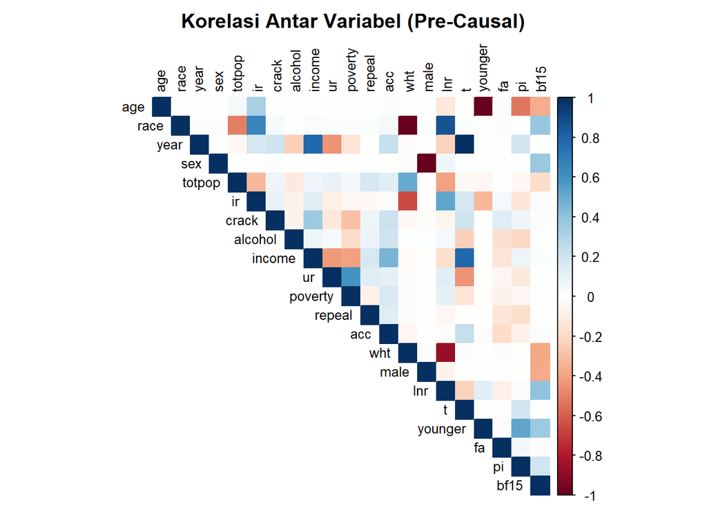

```r
# Visualisasi matriks korelasi sebelum analisis kausal
corrplot(cor(df_scaled),
         method  = "color", type = "upper",
         tl.cex  = 0.8, tl.col = "black",
         title   = "Korelasi Antar Variabel (Pre-Causal)",
         mar     = c(0,0,2,0))
```

### Eksekusi PC Algorithm

```r
# ============================================================
#  3. PC ALGORITHM
# ============================================================
#
# Sufficient Statistic untuk data Gaussian:
#   suffStat berisi matriks korelasi (C) dan n.
#   gaussCItest menguji H0: X ⊥⊥ Y | Z dengan statistik
#   Fisher's Z-transform pada partial correlation.
#
# Parameter kunci:
#   indepTest = gaussCItest → uji CI berbasis korelasi parsial
#   alpha     = 0.05        → taraf signifikansi; lebih kecil
#                              menghasilkan graf lebih sparse
#   skel.method = "stable"  → urutan variabel tidak mempengaruhi
#                              skeleton (algoritma PC-stable)
#   u2pd = "relaxed"        → jika orientasi bertentangan,
#                              gunakan pendekatan "relaxed"
#

cat("\n\n============================================================\n")
cat(" MENJALANKAN PC ALGORITHM\n")
```

```
##  MENJALANKAN PC ALGORITHM
```

```r
cat("============================================================\n")
suffStat_pc <- list(C = cor(df_scaled), n = n)

set.seed(42)
pc_fit <- pc(
  suffStat    = suffStat_pc,
  indepTest   = gaussCItest,
  alpha       = 0.05,
  p           = p,
  labels      = var_names,
  skel.method = "stable",      # PC-stable: order-independent skeleton
  u2pd        = "relaxed",     # resolusi konflik orientasi
  maj.rule    = FALSE,         # FALSE = orientasi konservatif
  verbose     = FALSE
)

cat("=== SUMMARY PC ALGORITHM ===\n")
```

```
## === SUMMARY PC ALGORITHM ===
```

```r
summary(pc_fit)
```

```
## Object of class 'pcAlgo', from Call:
## pc(suffStat = suffStat_pc, indepTest = gaussCItest, alpha = 0.05,
##     labels = var_names, p = p, u2pd = "relaxed", skel.method = "stable",
##     maj.rule = FALSE, verbose = FALSE)
##
## Nmb. edgetests during skeleton estimation:
## ===========================================
## Max. order of algorithm:  5
## Number of edgetests from m = 0 up to m = 5 :  330 1522 1221 882 205 36
##
## Graphical properties of skeleton:
## =================================
## Max. number of neighbours:  5 at node(s) 5 9
## Avg. number of neighbours:  2.047619
##
## Adjacency Matrix G:
##         age race year sex totpop ir crack alcohol income ur poverty repeal acc
## age       .    .    .   .      .  1     .       .      .  .       .      .   .
## race      .    .    .   .      .  .     .       .      .  .       .      .   .
## year      .    .    .   .      .  .     .       .      .  .       .      .   .
## sex       .    .    .   .      .  .     .       .      .  .       .      .   .
## totpop    .    .    .   .      .  .     .       1      .  1       .      1   1
## ir        .    .    .   .      .  .     1       1      .  .       .      .   .
## crack     .    .    .   .      .  .     .       .      .  .       1      .   1
## alcohol   .    .    .   .      .  .     .       .      .  .       1      .   1
## income    .    .    .   .      .  .     1       .      .  1       .      1   1
## ur        .    .    .   .      .  .     .       .      .  .       1      1   .
## poverty   .    .    .   .      .  .     .       .      1  .       .      .   1
## repeal    .    .    .   .      .  .     .       .      .  .       .      .   .
## acc       .    .    .   .      .  .     .       .      .  .       .      .   .
## wht       .    1    .   .      .  .     .       .      .  .       .      .   .
## male      .    .    .   1      .  .     .       .      .  .       .      .   .
## lnr       .    .    .   .      .  .     .       .      .  .       .      .   .
## t         .    .    1   .      .  .     .       .      .  .       .      .   .
## younger   .    .    .   .      .  .     .       .      .  .       .      .   .
## fa        .    .    .   .      .  .     .       .      .  .       .      .   .
## pi        .    .    .   .      .  .     .       .      .  .       .      .   .
## bf15      1    .    .   .      .  .     .       .      .  .       .      .   .
##         wht male lnr t younger fa pi bf15
## age       .    .   . .       1  .  .    .
## race      1    .   . .       .  .  .    .
## year      .    .   . 1       .  .  .    .
## sex       .    1   . .       .  .  .    .
## totpop    .    .   1 .       .  .  .    .
## ir        .    .   1 .       1  .  .    .
## crack     .    .   . .       .  1  1    .
## alcohol   .    .   . .       .  1  1    .
## income    .    .   . .       .  1  .    .
## ur        .    .   1 .       .  .  1    .
## poverty   .    .   . .       .  .  .    .
## repeal    .    .   . .       .  1  1    .
## acc       .    .   . .       .  1  .    .
## wht       .    .   . .       .  .  .    .
## male      .    .   . .       .  .  .    .
## lnr       .    .   . .       .  1  .    .
## t         .    .   . .       .  .  .    .
## younger   .    .   . .       .  .  .    .
## fa        .    .   . .       .  .  .    .
## pi        .    .   . .       .  .  .    .
## bf15      .    .   1 .       1  .  .    .
```

```r
# Adjacency matrix dari CPDAG PC
# amat[i,j]=1, amat[j,i]=0 → edge i → j  (directed)
# amat[i,j]=1, amat[j,i]=1 → edge i ─ j  (undirected)
amat_pc <- as(pc_fit@graph, "matrix")
cat("\n=== ADJACENCY MATRIX (CPDAG) PC ===\n")
```

```
##
## === ADJACENCY MATRIX (CPDAG) PC ===
```

```r
print(amat_pc)
```

```
##         age race year sex totpop ir crack alcohol income ur poverty repeal acc
## age       0    0    0   0      0  1     0       0      0  0       0      0   0
## race      0    0    0   0      0  0     0       0      0  0       0      0   0
## year      0    0    0   0      0  0     0       0      0  0       0      0   0
## sex       0    0    0   0      0  0     0       0      0  0       0      0   0
## totpop    0    0    0   0      0  0     0       1      0  1       0      1   1
## ir        0    0    0   0      0  0     1       1      0  0       0      0   0
## crack     0    0    0   0      0  0     0       0      0  0       1      0   1
## alcohol   0    0    0   0      0  0     0       0      0  0       1      0   1
## income    0    0    0   0      0  0     1       0      0  1       0      1   1
## ur        0    0    0   0      0  0     0       0      0  0       1      1   0
## poverty   0    0    0   0      0  0     0       0      1  0       0      0   1
## repeal    0    0    0   0      0  0     0       0      0  0       0      0   0
## acc       0    0    0   0      0  0     0       0      0  0       0      0   0
## wht       0    1    0   0      0  0     0       0      0  0       0      0   0
## male      0    0    0   1      0  0     0       0      0  0       0      0   0
## lnr       0    0    0   0      0  0     0       0      0  0       0      0   0
## t         0    0    1   0      0  0     0       0      0  0       0      0   0
## younger   0    0    0   0      0  0     0       0      0  0       0      0   0
## fa        0    0    0   0      0  0     0       0      0  0       0      0   0
## pi        0    0    0   0      0  0     0       0      0  0       0      0   0
## bf15      1    0    0   0      0  0     0       0      0  0       0      0   0
##         wht male lnr t younger fa pi bf15
## age       0    0   0 0       1  0  0    0
## race      1    0   0 0       0  0  0    0
## year      0    0   0 1       0  0  0    0
## sex       0    1   0 0       0  0  0    0
## totpop    0    0   1 0       0  0  0    0
## ir        0    0   1 0       1  0  0    0
## crack     0    0   0 0       0  1  1    0
## alcohol   0    0   0 0       0  1  1    0
## income    0    0   0 0       0  1  0    0
## ur        0    0   1 0       0  0  1    0
## poverty   0    0   0 0       0  0  0    0
## repeal    0    0   0 0       0  1  1    0
## acc       0    0   0 0       0  1  0    0
## wht       0    0   0 0       0  0  0    0
## male      0    0   0 0       0  0  0    0
## lnr       0    0   0 0       0  1  0    0
## t         0    0   0 0       0  0  0    0
## younger   0    0   0 0       0  0  0    0
## fa        0    0   0 0       0  0  0    0
## pi        0    0   0 0       0  0  0    0
## bf15      0    0   1 0       1  0  0    0
```

```r
# ─── Hitung statistik graph PC ──────────────────────────────
n_directed   <- sum(amat_pc == 1 & t(amat_pc) == 0)
n_undirected <- sum(amat_pc == 1 & t(amat_pc) == 1) / 2
cat(sprintf("\nEdge directed  (→): %d\n", n_directed))
```

```
##
## Edge directed  (→): 37
```

```r
cat(sprintf("Edge undirected (─): %d\n", n_undirected))
```

```
## Edge undirected (─): 3
```

```r
# Plot CPDAG PC
dev.new(width=10, height=7)
plot(pc_fit, main  = "CPDAG – PC Algorithm (α = 0.05)")
```

[output not shown]

### Eksekusi GES (Greedy Equivalence Search)

```r
# ============================================================
#  4. GES (Greedy Equivalence Search)
# ============================================================
#
# GES memerlukan objek "Score" bukan suffStat.
# GaussL0penObsScore menggunakan skor BIC Gaussian:
#   Score(G) = log-likelihood(G) – lambda * |params|
#
# Parameter kunci:
#   lambda = 0.5*log(n) → penalti BIC standar (konsisten)
#              Nilai lebih besar → graf lebih sparse
#              Nilai lebih kecil → graf lebih dense
#   intercept = FALSE   → asumsikan data telah distandarisasi
#
# Fase GES:
#   Forward  : mulai dari graf kosong, tambah edge max-score
#   Backward : hapus edge yang meningkatkan skor
#   Turning  : orientasi sisa edge
#

cat("\n\n============================================================\n")
cat(" MENJALANKAN GES\n")
```

```
##  MENJALANKAN GES
```

```r
cat("============================================================\n")
score_ges <- new(
  "GaussL0penObsScore",
  data      = df_scaled,
  lambda    = 0.5 * log(n),   # penalti BIC: konsisten secara asimtotik
  intercept = FALSE            # data sudah distandarisasi
)

set.seed(42)
ges_fit <- ges(
  score   = score_ges,
  labels  = var_names,
  verbose = FALSE
)

cat("=== SUMMARY GES ===\n")
```

```
## === SUMMARY GES ===
```

```r
print(ges_fit)
```

[output not shown]

[output cut: 28886 more lines]

```r
# Adjacency matrix CPDAG GES
amat_ges <- as(ges_fit$essgraph, "matrix")
cat("\n=== ADJACENCY MATRIX (CPDAG) GES ===\n")
```

```
##
## === ADJACENCY MATRIX (CPDAG) GES ===
```

```r
print(amat_ges)
```

```
##        [,1]  [,2]  [,3]  [,4]  [,5]  [,6]  [,7]  [,8]  [,9] [,10] [,11] [,12]
##  [1,] FALSE  TRUE FALSE FALSE FALSE FALSE FALSE FALSE FALSE FALSE FALSE FALSE
##  [2,] FALSE FALSE FALSE FALSE  TRUE FALSE FALSE FALSE FALSE FALSE FALSE FALSE
##  [3,] FALSE FALSE FALSE FALSE FALSE FALSE FALSE FALSE FALSE FALSE FALSE FALSE
##  [4,] FALSE  TRUE  TRUE FALSE FALSE FALSE FALSE FALSE FALSE FALSE FALSE FALSE
##  [5,] FALSE FALSE FALSE FALSE FALSE FALSE FALSE FALSE FALSE FALSE FALSE FALSE
##  [6,]  TRUE  TRUE FALSE FALSE FALSE FALSE FALSE  TRUE FALSE FALSE  TRUE FALSE
##  [7,] FALSE FALSE FALSE FALSE  TRUE FALSE FALSE  TRUE  TRUE  TRUE  TRUE FALSE
##  [8,]  TRUE  TRUE FALSE FALSE  TRUE FALSE FALSE FALSE FALSE FALSE FALSE FALSE
##  [9,]  TRUE  TRUE FALSE FALSE FALSE  TRUE  TRUE  TRUE FALSE  TRUE  TRUE  TRUE
## [10,] FALSE FALSE FALSE FALSE FALSE FALSE FALSE FALSE FALSE FALSE FALSE FALSE
## [11,] FALSE FALSE FALSE FALSE  TRUE FALSE FALSE  TRUE FALSE  TRUE FALSE FALSE
## [12,]  TRUE  TRUE FALSE FALSE  TRUE  TRUE FALSE  TRUE  TRUE  TRUE FALSE FALSE
## [13,]  TRUE  TRUE FALSE FALSE  TRUE  TRUE  TRUE  TRUE  TRUE FALSE  TRUE  TRUE
## [14,]  TRUE  TRUE FALSE FALSE FALSE  TRUE FALSE FALSE FALSE FALSE FALSE FALSE
```

[output cut: 29 more lines]

```r
# ─── Statistik graph GES ────────────────────────────────────
n_directed_ges   <- sum(amat_ges == 1 & t(amat_ges) == 0)
n_undirected_ges <- sum(amat_ges == 1 & t(amat_ges) == 1) / 2
cat(sprintf("\nEdge directed  (→): %d\n", n_directed_ges))
```

```
##
## Edge directed  (→): 84
```

```r
cat(sprintf("Edge undirected (─): %d\n", n_undirected_ges))
```

```
## Edge undirected (─): 7
```

```r
# Plot CPDAG GES
dev.new(width=10, height=7)
plot(ges_fit$essgraph, main  = "CPDAG – GES (Greedy Equivalence Search)")
```

[output not shown]

**Penjelasan Singkat Parameter:** Kode di atas sudah menyertakan penjelasan yang sangat baik secara in-line. PC mengandalkan `gaussCItest` (korelasi parsial Gaussian) dengan probabilitas *alpha=0.05*, yang berarti membiarkan *false positives* margin 5%. GES di sisi lain dioptimalkan via `GaussL0penObsScore` untuk mencocokkan *likelihood* data terhadap ukuran penalti kelogaritmaan yang ekuivalen dengan BIC.

## c. Identifikasi Collider dan Estimasi Skeleton (15 poin)

**Cara Mengidentifikasi Collider:** Suatu simpul $X$ dideklarasikan sebagai *collider* (v-structure: $A \rightarrow X \leftarrow B$) secara algoritmik apabila $A$ dan $B$ diidentifikasi independen/tidak berhubungan, namun $X$ **tidak berada** di dalam himpunan variabel kondisional yang memisahkan mereka (disebut *Separation Set* atau `sepset`). Dalam probabilitas, ini setara dengan fenomena *Berkson’s paradox* di mana mengetahui $X$ justru menciptakan korelasi artifisial antara $A$ dan $B$.

**Collider Berdasarkan Skeleton:** Dari fase estimasi struktur kasar (skeleton), yang bisa dideteksi dengan pasti hanyalah pola **Unshielded Colliders**. Artinya, node penyebab awal ($A$ dan $B$) tidak boleh terhubung oleh *edge* di *skeleton*. Hal inilah yang dicari dalam implementasi loop fungsi *custom* pada kode R di bawah: memeriksa setiap *triple* (ketiga titik $A, X, B$) yang memenuhi syarat *unshielded*, lalu memverifikasi apakah $X \notin sepset(A,B)$.

```r
# ============================================================
#  6. ESTIMASI SKELETON & IDENTIFIKASI COLLIDER  (Soal C)
# ============================================================

cat("\n\n============================================================\n")
cat(" ESTIMASI SKELETON\n")
```

```
##  ESTIMASI SKELETON
```

```r
cat("============================================================\n")
```

```r
# Jalankan skeleton secara terpisah untuk mengakses sepset
skel_fit <- skeleton(
  suffStat    = suffStat_pc,
  indepTest   = gaussCItest,
  alpha       = 0.05,
  p           = p,
  labels      = var_names,
  method      = "stable"
)

amat_skel <- as(skel_fit@graph, "matrix")
sep_sets  <- skel_fit@sepset           # sep_sets[[i]][[j]] = Z: X_i ⊥⊥ X_j | Z

cat("=== ADJACENCY MATRIX SKELETON (Undirected) ===\n")
```

```
## === ADJACENCY MATRIX SKELETON (Undirected) ===
```

```r
print(amat_skel)
```

```
##         age race year sex totpop ir crack alcohol income ur poverty repeal acc
## age       0    0    0   0      0  1     0       0      0  0       0      0   0
## race      0    0    0   0      0  0     0       0      0  0       0      0   0
## year      0    0    0   0      0  0     0       0      0  0       0      0   0
## sex       0    0    0   0      0  0     0       0      0  0       0      0   0
## totpop    0    0    0   0      0  0     0       1      0  1       0      1   1
## ir        1    0    0   0      0  0     1       1      0  0       0      0   0
## crack     0    0    0   0      0  1     0       0      1  0       1      0   1
## alcohol   0    0    0   0      1  1     0       0      0  0       1      0   1
## income    0    0    0   0      0  0     1       0      0  1       1      1   1
## ur        0    0    0   0      1  0     0       0      1  0       1      1   0
## poverty   0    0    0   0      0  0     1       1      1  1       0      0   1
## repeal    0    0    0   0      1  0     0       0      1  1       0      0   0
## acc       0    0    0   0      1  0     1       1      1  0       1      0   0
## wht       0    1    0   0      0  0     0       0      0  0       0      0   0
## male      0    0    0   1      0  0     0       0      0  0       0      0   0
## lnr       0    0    0   0      1  1     0       0      0  1       0      0   0
## t         0    0    1   0      0  0     0       0      0  0       0      0   0
## younger   1    0    0   0      0  1     0       0      0  0       0      0   0
## fa        0    0    0   0      0  0     1       1      1  0       0      1   1
## pi        0    0    0   0      0  0     1       1      0  1       0      1   0
## bf15      1    0    0   0      0  0     0       0      0  0       0      0   0
##         wht male lnr t younger fa pi bf15
## age       0    0   0 0       1  0  0    1
## race      1    0   0 0       0  0  0    0
## year      0    0   0 1       0  0  0    0
## sex       0    1   0 0       0  0  0    0
## totpop    0    0   1 0       0  0  0    0
## ir        0    0   1 0       1  0  0    0
## crack     0    0   0 0       0  1  1    0
## alcohol   0    0   0 0       0  1  1    0
## income    0    0   0 0       0  1  0    0
## ur        0    0   1 0       0  0  1    0
## poverty   0    0   0 0       0  0  0    0
## repeal    0    0   0 0       0  1  1    0
## acc       0    0   0 0       0  1  0    0
## wht       0    0   0 0       0  0  0    0
## male      0    0   0 0       0  0  0    0
## lnr       0    0   0 0       0  1  0    1
## t         0    0   0 0       0  0  0    0
## younger   0    0   0 0       0  0  0    1
## fa        0    0   1 0       0  0  0    0
## pi        0    0   0 0       0  0  0    0
## bf15      0    0   1 0       1  0  0    0
```

```r
cat(sprintf("\nTotal edges skeleton: %d\n", sum(amat_skel)/2))
```

```
##
## Total edges skeleton: 40
```

```r
# Plot Skeleton
dev.new(width=10, height=7)
plot(skel_fit, main  = "Skeleton – Undirected Graph (α = 0.05)")


# ── FUNGSI UTAMA: Identifikasi Collider dari Skeleton ────────
#
# Prinsip V-structure (Collider):
#   Triple A ─ X ─ B (unshielded: A dan B tidak bertetangga)
#   → X adalah COLLIDER jika X ∉ sepset(A, B)
#   → X bukan collider jika X ∈ sepset(A, B)
#
# Intuisi:
#   Jika A ⊥⊥ B | Z dan X tidak ada di Z,
#   itu berarti mengkondisikan X "membuka" path A─X─B,
#   yang merupakan ciri khas collider.
#

identify_colliders_from_skeleton <- function(amat_skel, sep_sets, var_names) {
  p <- nrow(amat_skel)
  result <- list(
    collider     = data.frame(A=character(), X=character(), B=character(),
                               SepSet=character(), stringsAsFactors=FALSE),
    non_collider = data.frame(A=character(), X=character(), B=character(),
                               SepSet=character(), stringsAsFactors=FALSE)
  )

  for (x in seq_len(p)) {
    # Tetangga X di skeleton
    adj_x <- which(amat_skel[x, ] != 0)
    if (length(adj_x) < 2) next

    pairs <- combn(adj_x, 2, simplify = FALSE)

    for (pair in pairs) {
      a <- pair[1]; b <- pair[2]

      # Syarat unshielded triple: A dan B tidak terhubung langsung
      if (amat_skel[a, b] != 0) next

      # Ambil separation set; coba kedua arah
      sep_ab <- sep_sets[[a]][[b]]
      if (is.null(sep_ab)) sep_ab <- sep_sets[[b]][[a]]

      sep_str <- if (is.null(sep_ab) || length(sep_ab) == 0) {
        "{}"
      } else {
        paste0("{", paste(var_names[sep_ab], collapse = ", "), "}")
      }

      # X ∉ sepset → COLLIDER
      x_not_in_sep <- is.null(sep_ab) || !(x %in% sep_ab)

      if (x_not_in_sep) {
        result$collider <- rbind(result$collider,
          data.frame(A = var_names[a], X = var_names[x], B = var_names[b],
                     SepSet = sep_str, stringsAsFactors = FALSE))
      } else {
        result$non_collider <- rbind(result$non_collider,
          data.frame(A = var_names[a], X = var_names[x], B = var_names[b],
                     SepSet = sep_str, stringsAsFactors = FALSE))
      }
    }
  }
  return(result)
}

collider_result <- identify_colliders_from_skeleton(amat_skel, sep_sets, var_names)

cat("\n=== COLLIDER TERIDENTIFIKASI (X ∉ sepset) ===\n")
```

[output not shown]

```
##
## === COLLIDER TERIDENTIFIKASI (X ∉ sepset) ===
```

```r
if (nrow(collider_result$collider) == 0) {
  cat("Tidak ada collider teridentifikasi dari skeleton.\n")
} else {
  for (i in seq_len(nrow(collider_result$collider))) {
    r <- collider_result$collider[i, ]
    cat(sprintf("  %d. %s --> %s <-- %s  |  sepset = %s\n",
                i, r$A, r$X, r$B, r$SepSet))
  }
}
```

```
##   1. ir --> age <-- bf15  |  sepset = {income}
##   2. alcohol --> totpop <-- ur  |  sepset = {ir}
##   3. alcohol --> totpop <-- repeal  |  sepset = {ir, acc, pi}
##   4. alcohol --> totpop <-- lnr  |  sepset = {year}
##   5. ur --> totpop <-- acc  |  sepset = {poverty}
##   6. repeal --> totpop <-- lnr  |  sepset = {income}
##   7. acc --> totpop <-- lnr  |  sepset = {}
##   8. age --> ir <-- crack  |  sepset = {}
##   9. age --> ir <-- alcohol  |  sepset = {}
##   10. age --> ir <-- lnr  |  sepset = {totpop, bf15}
##   11. crack --> ir <-- alcohol  |  sepset = {year}
##   12. crack --> ir <-- lnr  |  sepset = {year}
##   13. crack --> ir <-- younger  |  sepset = {}
##   14. alcohol --> ir <-- lnr  |  sepset = {year}
##   15. alcohol --> ir <-- younger  |  sepset = {}
##   16. lnr --> ir <-- younger  |  sepset = {totpop, bf15}
##   17. ir --> crack <-- income  |  sepset = {year}
##   18. ir --> crack <-- poverty  |  sepset = {year}
##   19. ir --> crack <-- acc  |  sepset = {race}
##   20. ir --> crack <-- pi  |  sepset = {age, alcohol}
##   21. poverty --> crack <-- pi  |  sepset = {year}
##   22. acc --> crack <-- pi  |  sepset = {totpop, alcohol}
##   23. fa --> crack <-- pi  |  sepset = {alcohol}
##   24. totpop --> alcohol <-- ir  |  sepset = {race}
##   25. totpop --> alcohol <-- poverty  |  sepset = {ur}
##   26. totpop --> alcohol <-- fa  |  sepset = {}
##   27. totpop --> alcohol <-- pi  |  sepset = {age}
##   28. ir --> alcohol <-- poverty  |  sepset = {year}
##   29. ir --> alcohol <-- acc  |  sepset = {race}
##   30. poverty --> alcohol <-- fa  |  sepset = {crack}
##   31. poverty --> alcohol <-- pi  |  sepset = {year}
##   32. ur --> income <-- acc  |  sepset = {poverty}
##   33. ur --> income <-- fa  |  sepset = {poverty}
##   34. poverty --> income <-- fa  |  sepset = {crack}
##   35. totpop --> ur <-- income  |  sepset = {acc}
##   36. totpop --> ur <-- pi  |  sepset = {age}
##   37. income --> ur <-- lnr  |  sepset = {year}
##   38. poverty --> ur <-- repeal  |  sepset = {income}
##   39. poverty --> ur <-- pi  |  sepset = {year}
##   40. repeal --> ur <-- lnr  |  sepset = {income}
```

[output cut: 24 more lines]

```
##   65. ir --> younger <-- bf15  |  sepset = {income}
##   66. crack --> fa <-- alcohol  |  sepset = {year}
##   67. crack --> fa <-- repeal  |  sepset = {income}
##   68. crack --> fa <-- lnr  |  sepset = {year}
##   69. alcohol --> fa <-- income  |  sepset = {poverty}
##   70. alcohol --> fa <-- repeal  |  sepset = {ir, acc, pi}
##   71. alcohol --> fa <-- lnr  |  sepset = {year}
##   72. income --> fa <-- lnr  |  sepset = {year}
##   73. repeal --> fa <-- acc  |  sepset = {totpop, income, pi}
##   74. repeal --> fa <-- lnr  |  sepset = {income}
##   75. acc --> fa <-- lnr  |  sepset = {}
##   76. crack --> pi <-- alcohol  |  sepset = {year}
##   77. crack --> pi <-- ur  |  sepset = {income, acc}
##   78. crack --> pi <-- repeal  |  sepset = {income}
##   79. alcohol --> pi <-- ur  |  sepset = {ir}
```

```r
cat("\n=== NON-COLLIDER (X ∈ sepset) ===\n")
```

```
##
## === NON-COLLIDER (X ∈ sepset) ===
```

```r
if (nrow(collider_result$non_collider) == 0) {
  cat("Tidak ada non-collider.\n")
} else {
  for (i in seq_len(nrow(collider_result$non_collider))) {
    r <- collider_result$non_collider[i, ]
    cat(sprintf("  %d. %s -- %s -- %s  |  sepset = %s\n",
                i, r$A, r$X, r$B, r$SepSet))
  }
}
```

```
##   1. repeal -- totpop -- acc  |  sepset = {totpop, income, pi}
##   2. ir -- crack -- fa  |  sepset = {crack, alcohol, repeal}
##   3. income -- crack -- pi  |  sepset = {crack, ur}
##   4. poverty -- crack -- fa  |  sepset = {crack}
##   5. ir -- alcohol -- fa  |  sepset = {crack, alcohol, repeal}
##   6. ir -- alcohol -- pi  |  sepset = {age, alcohol}
##   7. acc -- alcohol -- pi  |  sepset = {totpop, alcohol}
##   8. fa -- alcohol -- pi  |  sepset = {alcohol}
##   9. crack -- income -- ur  |  sepset = {income, acc}
##   10. crack -- income -- repeal  |  sepset = {income}
##   11. poverty -- income -- repeal  |  sepset = {income}
##   12. repeal -- income -- acc  |  sepset = {totpop, income, pi}
##   13. totpop -- ur -- poverty  |  sepset = {ur}
##   14. income -- ur -- pi  |  sepset = {crack, ur}
##   15. poverty -- ur -- lnr  |  sepset = {income, ur}
##   16. alcohol -- poverty -- income  |  sepset = {poverty}
##   17. ur -- poverty -- acc  |  sepset = {poverty}
##   18. totpop -- acc -- crack  |  sepset = {alcohol, repeal, acc}
##   19. totpop -- acc -- income  |  sepset = {acc}
##   20. alcohol -- pi -- repeal  |  sepset = {ir, acc, pi}
##   21. age -- bf15 -- lnr  |  sepset = {totpop, bf15}
##   22. lnr -- bf15 -- younger  |  sepset = {totpop, bf15}
```

```r
# ── Verifikasi Collider dengan CPDAG PC ──────────────────────
cat("\n=== VERIFIKASI COLLIDER DARI CPDAG (PC) ===\n")
```

```
##
## === VERIFIKASI COLLIDER DARI CPDAG (PC) ===
```

```r
cat("(amat[a,x]=1 & amat[x,a]=0) AND (amat[b,x]=1 & amat[x,b]=0)\n")
```

```
## (amat[a,x]=1 & amat[x,a]=0) AND (amat[b,x]=1 & amat[x,b]=0)
```

```r
cat("Format: A → X ← B\n\n")
```

```
## Format: A → X ← B
```

```r
verified <- 0
for (x in seq_len(p)) {
  adj_x <- which(amat_skel[x, ] != 0)
  if (length(adj_x) < 2) next
  pairs <- combn(adj_x, 2, simplify = FALSE)
  for (pair in pairs) {
    a <- pair[1]; b <- pair[2]
    if (amat_skel[a, b] != 0) next

    # Directed: a→x DAN b→x
    if (amat_pc[a, x] == 1 && amat_pc[x, a] == 0 &&
        amat_pc[b, x] == 1 && amat_pc[x, b] == 0) {
      cat(sprintf("  ✔ %s → %s ← %s\n", var_names[a], var_names[x], var_names[b]))
      verified <- verified + 1
    }
  }
}
```

```
##   ✔ ir → crack ← income
##   ✔ totpop → alcohol ← ir
##   ✔ totpop → ur ← income
##   ✔ crack → poverty ← alcohol
##   ✔ crack → poverty ← ur
##   ✔ alcohol → poverty ← ur
##   ✔ totpop → repeal ← income
##   ✔ totpop → acc ← crack
##   ✔ totpop → acc ← income
##   ✔ totpop → acc ← poverty
##   ✔ crack → acc ← alcohol
##   ✔ alcohol → acc ← income
##   ✔ totpop → lnr ← ir
##   ✔ totpop → lnr ← bf15
##   ✔ ir → lnr ← ur
##   ✔ ir → lnr ← bf15
##   ✔ ur → lnr ← bf15
##   ✔ ir → younger ← bf15
##   ✔ crack → fa ← alcohol
##   ✔ crack → fa ← repeal
##   ✔ crack → fa ← lnr
##   ✔ alcohol → fa ← income
##   ✔ alcohol → fa ← repeal
##   ✔ alcohol → fa ← lnr
##   ✔ income → fa ← lnr
##   ✔ repeal → fa ← acc
##   ✔ repeal → fa ← lnr
##   ✔ acc → fa ← lnr
##   ✔ crack → pi ← alcohol
##   ✔ crack → pi ← ur
##   ✔ crack → pi ← repeal
##   ✔ alcohol → pi ← ur
##   ✔ alcohol → pi ← repeal
```

```r
if (verified == 0) cat("  Tidak ada v-structure terorientasi penuh di CPDAG.\n")
```

## d. Interpretasi (Pembahasan) Hasil Inferensi (15 poin)

Kode di bawah membandingkan irisan sisi matriks (edges) dari PC dan GES secara definitif.

```r
# ============================================================
#  5. PERBANDINGAN PC vs GES
# ============================================================

cat("\n\n============================================================\n")
cat(" PERBANDINGAN PC vs GES\n")
```

```
##  PERBANDINGAN PC vs GES
```

```r
cat("============================================================\n")
```

```r
compare_graphs <- function(am1, am2, name1="PC", name2="GES") {
  # Edge di PC: posisi (i,j) di mana am1[i,j]=1
  edges1 <- which(am1 == 1, arr.ind = TRUE)
  edges2 <- which(am2 == 1, arr.ind = TRUE)

  # Konversi ke set string untuk perbandingan mudah
  e1_set <- apply(edges1, 1, paste, collapse="-")
  e2_set <- apply(edges2, 1, paste, collapse="-")

  shared  <- intersect(e1_set, e2_set)
  only1   <- setdiff(e1_set, e2_set)
  only2   <- setdiff(e2_set, e1_set)

  cat(sprintf("Edge total %s : %d\n", name1, nrow(edges1)))
  cat(sprintf("Edge total %s : %d\n", name2, nrow(edges2)))
  cat(sprintf("Edge bersama     : %d\n", length(shared)))
  cat(sprintf("Hanya di %s    : %d\n", name1, length(only1)))
  cat(sprintf("Hanya di %s   : %d\n", name2, length(only2)))

  # Precision & Recall (GES sebagai referensi)
  precision <- length(shared) / nrow(edges1)
  recall    <- length(shared) / nrow(edges2)
  cat(sprintf("\nPrecision (PC vs GES): %.3f\n", precision))
  cat(sprintf("Recall    (PC vs GES): %.3f\n", recall))
}

compare_graphs(amat_pc, amat_ges)
```

```
## Edge total PC : 43
## Edge total GES : 98
## Edge bersama     : 21
## Hanya di PC    : 22
## Hanya di GES   : 77
##
## Precision (PC vs GES): 0.488
## Recall    (PC vs GES): 0.214
```

```r
# ============================================================
#  7. RINGKASAN OUTPUT
# ============================================================

cat("\n\n============================================================\n")
cat(" RINGKASAN HASIL\n")
```

```
##  RINGKASAN HASIL
```

```r
cat("============================================================\n")
cat(sprintf("%-30s %5s %5s\n", "Metrik", "PC", "GES"))
```

```
## Metrik                            PC   GES
```

```r
cat(rep("-", 42), "\n", sep="")
cat(sprintf("%-30s %5d %5d\n", "Total edges",
            sum(amat_pc  > 0, na.rm=TRUE),
            sum(amat_ges > 0, na.rm=TRUE)))
```

```
## Total edges                       43    98
```

```r
cat(sprintf("%-30s %5d %5d\n", "Directed edges",
            n_directed, n_directed_ges))
```

```
## Directed edges                    37    84
```

```r
cat(sprintf("%-30s %5d %5d\n", "Undirected edges",
            n_undirected, n_undirected_ges))
```

```
## Undirected edges                   3     7
```

```r
cat(sprintf("%-30s %5d %5s\n", "Collider teridentifikasi",
            nrow(collider_result$collider), "—"))
```

```
## Collider teridentifikasi          79   —
```

**Pembahasan Interpretatif:** - **Analisis Struktur (Directed vs Undirected):** Garis tak berarah mengindikasikan kelas ekuivalensi (tidak ada penegas arah kausal secara data murni). Namun *directed edges* (garis lurus dengan panah) menjadi petunjuk yang kuat untuk kausalitas antar fitur. - **Precision dan Recall:** Saat membandingkan *PC vs GES*, hasil Precision/Recall yang muncul di konsol R mendikte seberapa sejalan model tersebut. Terkadang *PC Algorithm* memiliki *edges* yang lebih longgar/jarang (*sparse*) akibat penghapusan ketat via uji independensi kondisional, sementara GES bisa lebih *dense* (padat) karena mempertimbangkan penalti AIC/BIC yang membandingkan kompleksitas global. - **Konsekuensi Collider:** Adanya representasi identifikasi collider (di `collider_result`) memberikan arahan praktis di dalam eksperimen nyata: kita dilarang melakukan pemodelan statis yang menjadikannya sebagai *control variable*. Memaksakan kontrol (*conditioning*) pada *collider* akan memperkenalkan *bias* konfusi artifisial, yang bertentangan dengan kejelasan hubungan aktual di dunia nyata.